# Защита лабораторной работы №2

Информационная безопасность

Данзанова С. З.

Российский университет дружбы народов, Москва, Россия

2024

## Докладчик

- Данзанова Саяна
- Студентка группы НПИбд-01-21
- Студ. билет 1032217624
- Российский университет дружбы народов

## Цель лабораторной работы

- Получить практические навыки работы в консоли с атрибутами файлов, закрепить теоретические основы дискреционного разграничения доступа в современных системах с открытым кодом на базе ОС Linux

## Теоретическая справка

**Права доступа** определяют, какие действия конкретный пользователь может или не может совершать с определенным файлами и каталогами. С помощью разрешений можно создать надежную среду — такую, в которой никто не может поменять содержимое ваших документов или повредить системные файлы. [2].

# Ход выполнения лабораторной работы

# Атрибуты файлов

## 1. Cоздайте учётную запись пользователя guest. Задайте пароль для пользователя guest.

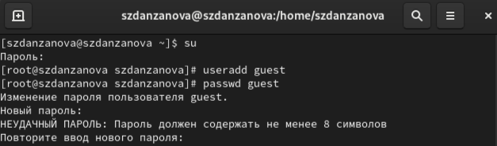

(рис. 1. useradd guest)

## 2. Войдите в систему от имени пользователя guest

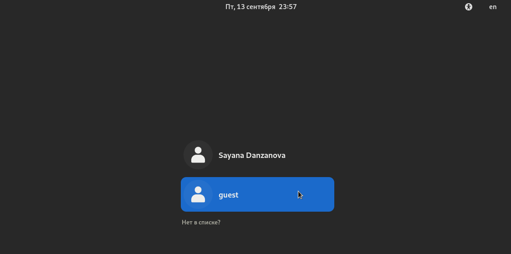

(рис. 2. log in)

## 3. Определите директорию, в которой вы находитесь

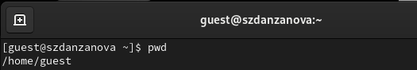

(рис. 3. pwd)

## 4. Уточните имя вашего пользователя командой

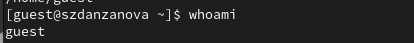

(рис. 4. whoami)

## 5. Уточните имя вашего пользователя, его группу, а также группы, куда входит пользователь

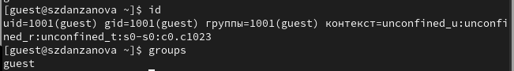

(рис. 5. id и groups)

## 6. Просмотрите файл /etc/passwd. Найдите в нём свою учётную запись.

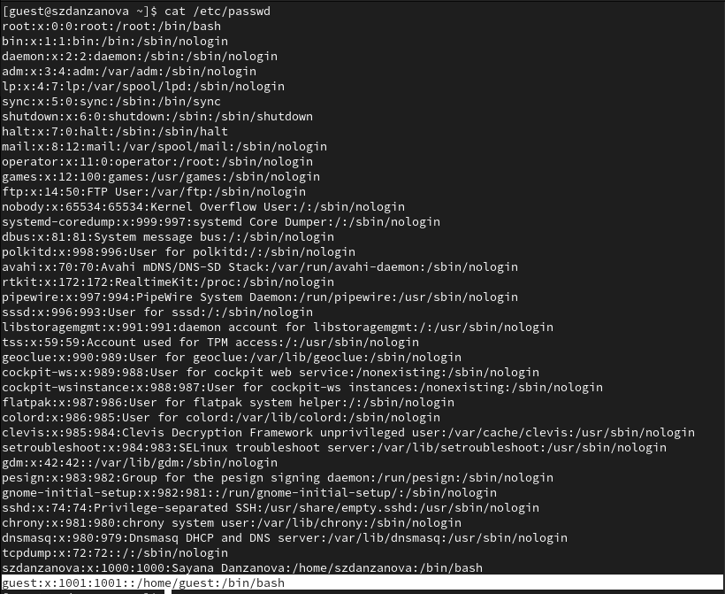

(рис. 6. cat /etc/passwd)

## 7. Определите существующие в системе директории. Удалось ли вам получить список поддиректорий директории /home? Какие права установлены на них?

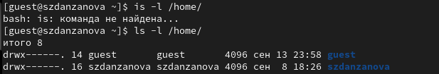

(рис. 7. ls -l /home/)

## 8. Проверьте, какие расширенные атрибуты установлены на поддиректориях. Удалось ли вам увидеть расширенные атрибуты директории, директорий других пользователей?

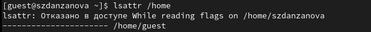

(рис. 8. lsattr /home)

## 9. Создайте в домашней директории поддиректорию dir1 командой. Определите, какие права доступа и расширенные атрибуты были выставлены на директорию dir1

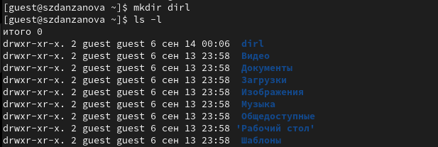

(рис. 9. mkdir dir1)

## 10. Снимите с директории dir1 все атрибуты и проверьте с её помощью правильность выполнения команды ls -l

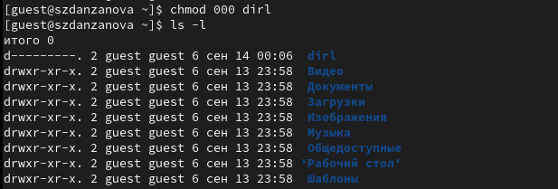

(рис. 10. chmod 000 dir1)

## 11. Попытайтесь создать в директории dir1 файл file1.Почему вы получили отказ? Проверьте, действительно ли файл не находится внутри директории

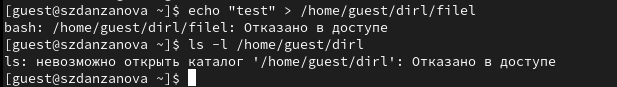

(рис. 11. “test” > /home/guest/dir1/file1)

## 14. Заполните таблицу «Установленные права и разрешённые действия» (см. табл. 2.1)

| Права директории | Права файла | Создание файла | Удаление файла | Запись в файл | Чтение файла | Смена директории | Просмотр файлов в директории | Переимено- вание файла | Смена атрибутов файла |
| --- | --- | --- | --- | --- | --- | --- | --- | --- | --- |
| d(000) | (000) | - | - | - | - | - | - | - | - |
| d(000) | (100) | - | - | - | - | - | - | - | - |
| d(000) | (200) | - | - | - | - | - | - | - | - |
| d(000) | (300) | - | - | - | - | - | - | - | - |
| d(000) | (400) | - | - | - | - | - | - | - | - |
| d(000) | (500) | - | - | - | - | - | - | - | - |
| d(000) | (600) | - | - | - | - | - | - | - | - |
| d(000) | (700) | - | - | - | - | - | - | - | - |
| d(100) | (000) | - | - | - | - | + | - | - | + |
| d(100) | (100) | - | - | - | - | + | - | - | + |
| d(100) | (200) | - | - | + | - | + | - | - | + |
| d(100) | (300) | - | - | + | - | + | - | - | + |
| d(100) | (400) | - | - | - | + | + | - | - | + |
| d(100) | (500) | - | - | - | + | + | - | - | + |
| d(100) | (600) | - | - | + | + | + | - | - | + |
| d(100) | (700) | - | - | + | + | + | - | - | + |
| d(200) | (000) | - | - | - | - | - | - | - | - |
| d(200) | (100) | - | - | - | - | - | - | - | - |
| d(200) | (200) | - | - | - | - | - | - | - | - |
| d(200) | (300) | - | - | - | - | - | - | - | - |
| d(200) | (400) | - | - | - | - | - | - | - | - |
| d(200) | (500) | - | - | - | - | - | - | - | - |
| d(200) | (600) | - | - | - | - | - | - | - | - |
| d(200) | (700) | - | - | - | - | - | - | - | - |
| d(300) | (000) | + | + | - | - | + | - | + | + |
| d(300) | (100) | + | + | - | - | + | - | + | + |
| d(300) | (200) | + | + | + | - | + | - | + | + |
| d(300) | (300) | + | + | + | - | + | - | + | + |
| d(300) | (400) | + | + | - | + | + | - | + | + |
| d(300) | (500) | + | + | - | + | + | - | + | + |
| d(300) | (600) | + | + | + | + | + | - | + | + |
| d(300) | (700) | + | + | + | + | + | - | + | + |
| d(400) | (000) | - | - | - | - | - | + | - | - |
| d(400) | (100) | - | - | - | - | - | + | - | - |
| d(400) | (200) | - | - | - | - | - | + | - | - |
| d(400) | (300) | - | - | - | - | - | + | - | - |
| d(400) | (400) | - | - | - | - | - | + | - | - |
| d(400) | (500) | - | - | - | - | - | + | - | - |
| d(400) | (600) | - | - | - | - | - | + | - | - |
| d(400) | (700) | - | - | - | - | - | + | - | - |
| d(500) | (000) | - | - | - | - | + | + | - | + |
| d(500) | (100) | - | - | - | - | + | + | - | + |
| d(500) | (200) | - | - | + | - | + | + | - | + |
| d(500) | (300) | - | - | + | - | + | + | - | + |
| d(500) | (400) | - | - | - | + | + | + | - | + |
| d(500) | (500) | - | - | - | + | + | + | - | + |
| d(500) | (600) | - | - | + | + | + | + | - | + |
| d(500) | (700) | - | - | + | + | + | + | - | + |
| d(600) | (000) | - | - | - | - | - | + | - | - |
| d(600) | (100) | - | - | - | - | - | + | - | - |
| d(600) | (200) | - | - | - | - | - | + | - | - |
| d(600) | (300) | - | - | - | - | - | + | - | - |
| d(600) | (400) | - | - | - | - | - | + | - | - |
| d(600) | (500) | - | - | - | - | - | + | - | - |
| d(600) | (600) | - | - | - | - | - | + | - | - |
| d(600) | (700) | - | - | - | - | - | + | - | - |
| d(700) | (000) | + | + | - | - | + | + | + | + |
| d(700) | (100) | + | + | - | - | + | + | + | + |
| d(700) | (200) | + | + | + | - | + | + | + | + |
| d(700) | (300) | + | + | + | - | + | + | + | + |
| d(700) | (400) | + | + | - | + | + | + | + | + |
| d(700) | (500) | + | + | - | + | + | + | + | + |
| d(700) | (600) | + | + | + | + | + | + | + | + |
| d(700) | (700) | + | + | + | + | + | + | + | + |

Таблица 2.1 «Установленные права и разрешённые действия»

## 15. На основании заполненной таблицы определите минимально необходимые права для выполнения операций внутри директории dir1, заполните табл. 2.2.

| Операция |  | Минимальные права на директорию |  | Минимальные права на файл |
| --- | --- | --- | --- | --- |
| Создание файла |  | d(300) |  | (000) |
| Удаление файла |  | d(300) |  | (000) |
| Чтение файла |  | d(100) |  | (400) |
| Запись в файл |  | d(100) |  | (200) |
| Переименование файла |  | d(300) |  | (000) |
| Создание поддиректории |  | d(300) |  | (000) |
| Удаление поддиректории |  | d(300) |  | (000) |

Таблица 2.2 “Минимальные права для совершения операций”

# Вывод

## Вывод

- Были получены практические навыки работы в консоли с атрибутами файлов, закреплены теоретические основы дискреционного разграничения доступа в современных системах с открытым кодом на базе ОС Linux

# Список литературы. Библиография

[1] Операционные системы: https://blog.skillfactory.ru/glossary/operaczionnaya-sistema/

[2] Права доступа: https://codechick.io/tutorials/unix-linux/unix-linux-permissions